# Risk Factor Analysis

## Outcome Variable

**Outcome Variable:** haz

## Predictor Variables

**Intervention Variable:** exclfeed36

**Adjustment Set:**

- arm
- sex
- brthmon
- W_mage
- meducyrs
- feducyrs
- hhwealth_quart
- hfoodsec
- W_mhtcm
- W_mwtkg
- W_mbmi
- vagbrth
- W_gagebrth
- W_birthwt
- W_birthlen
- W_nrooms
- W_nchldlt5
- month
- W_parity
- impfloor
- impsan
- safeh20
- delta_W_mage
- delta_meducyrs
- delta_feducyrs
- delta_hhwealth_quart
- delta_hfoodsec
- delta_W_mhtcm
- delta_W_mwtkg
- delta_W_mbmi
- delta_vagbrth
- delta_W_gagebrth
- delta_W_birthwt
- delta_W_birthlen
- delta_W_nrooms
- delta_W_nchldlt5
- delta_month
- delta_W_parity
- delta_impfloor
- delta_impsan
- delta_safeh20

## Stratifying Variables

The analysis was stratified on these variable(s):

- agecat
- studyid
- country

## Data Summary

| agecat | studyid | country | exclfeed36 | n_cell | n |
| --- | --- | --- | --- | --- | --- |
| Birth | ki0047075b-MAL-ED | BANGLADESH | 1 | 32 | 221 |
| Birth | ki0047075b-MAL-ED | BANGLADESH | 0 | 189 | 221 |
| Birth | ki0047075b-MAL-ED | BRAZIL | 1 | 5 | 65 |
| Birth | ki0047075b-MAL-ED | BRAZIL | 0 | 60 | 65 |
| Birth | ki0047075b-MAL-ED | INDIA | 1 | 1 | 42 |
| Birth | ki0047075b-MAL-ED | INDIA | 0 | 41 | 42 |
| Birth | ki0047075b-MAL-ED | NEPAL | 1 | 0 | 26 |
| Birth | ki0047075b-MAL-ED | NEPAL | 0 | 26 | 26 |
| Birth | ki0047075b-MAL-ED | PERU | 1 | 5 | 223 |
| Birth | ki0047075b-MAL-ED | PERU | 0 | 218 | 223 |
| Birth | ki0047075b-MAL-ED | SOUTH AFRICA | 1 | 1 | 105 |
| Birth | ki0047075b-MAL-ED | SOUTH AFRICA | 0 | 104 | 105 |
| Birth | ki0047075b-MAL-ED | TANZANIA, UNITED REPUBLIC OF | 1 | 0 | 119 |
| Birth | ki0047075b-MAL-ED | TANZANIA, UNITED REPUBLIC OF | 0 | 119 | 119 |
| Birth | ki1000108-CMC-V-BCS-2002 | INDIA | 1 | 3 | 3 |
| Birth | ki1000108-CMC-V-BCS-2002 | INDIA | 0 | 0 | 3 |
| Birth | ki1000108-IRC | INDIA | 1 | 0 | 4 |
| Birth | ki1000108-IRC | INDIA | 0 | 4 | 4 |
| Birth | ki1000109-EE | PAKISTAN | 1 | 3 | 7 |
| Birth | ki1000109-EE | PAKISTAN | 0 | 4 | 7 |
| Birth | ki1017093b-PROVIDE | BANGLADESH | 1 | 119 | 490 |
| Birth | ki1017093b-PROVIDE | BANGLADESH | 0 | 371 | 490 |
| Birth | ki1101329-Keneba | GAMBIA | 1 | 4 | 9 |
| Birth | ki1101329-Keneba | GAMBIA | 0 | 5 | 9 |
| Birth | ki1113344-GMS-Nepal | NEPAL | 1 | 422 | 526 |
| Birth | ki1113344-GMS-Nepal | NEPAL | 0 | 104 | 526 |
| Birth | kiGH5241-JiVitA-3 | BANGLADESH | 1 | 9840 | 12642 |
| Birth | kiGH5241-JiVitA-3 | BANGLADESH | 0 | 2802 | 12642 |
| Birth | kiGH5241-JiVitA-4 | BANGLADESH | 1 | 1994 | 2517 |
| Birth | kiGH5241-JiVitA-4 | BANGLADESH | 0 | 523 | 2517 |

[output cut: 66 more lines]

The following strata were considered:

- agecat: 24 months, studyid: ki0047075b-MAL-ED, country: BANGLADESH
- agecat: 24 months, studyid: ki0047075b-MAL-ED, country: BRAZIL
- agecat: 24 months, studyid: ki0047075b-MAL-ED, country: INDIA
- agecat: 24 months, studyid: ki0047075b-MAL-ED, country: NEPAL
- agecat: 24 months, studyid: ki0047075b-MAL-ED, country: PERU
- agecat: 24 months, studyid: ki0047075b-MAL-ED, country: SOUTH AFRICA
- agecat: 24 months, studyid: ki0047075b-MAL-ED, country: TANZANIA, UNITED REPUBLIC OF
- agecat: 24 months, studyid: ki1000108-CMC-V-BCS-2002, country: INDIA
- agecat: 24 months, studyid: ki1000108-IRC, country: INDIA
- agecat: 24 months, studyid: ki1000109-EE, country: PAKISTAN
- agecat: 24 months, studyid: ki1017093b-PROVIDE, country: BANGLADESH
- agecat: 24 months, studyid: ki1101329-Keneba, country: GAMBIA
- agecat: 24 months, studyid: ki1113344-GMS-Nepal, country: NEPAL
- agecat: 24 months, studyid: ki1148112-LCNI-5, country: MALAWI
- agecat: 24 months, studyid: kiGH5241-JiVitA-3, country: BANGLADESH
- agecat: 24 months, studyid: kiGH5241-JiVitA-4, country: BANGLADESH
- agecat: 6 months, studyid: ki0047075b-MAL-ED, country: BANGLADESH
- agecat: 6 months, studyid: ki0047075b-MAL-ED, country: BRAZIL
- agecat: 6 months, studyid: ki0047075b-MAL-ED, country: INDIA
- agecat: 6 months, studyid: ki0047075b-MAL-ED, country: NEPAL
- agecat: 6 months, studyid: ki0047075b-MAL-ED, country: PERU
- agecat: 6 months, studyid: ki0047075b-MAL-ED, country: SOUTH AFRICA
- agecat: 6 months, studyid: ki0047075b-MAL-ED, country: TANZANIA, UNITED REPUBLIC OF
- agecat: 6 months, studyid: ki1000108-CMC-V-BCS-2002, country: INDIA
- agecat: 6 months, studyid: ki1000108-IRC, country: INDIA
- agecat: 6 months, studyid: ki1000109-EE, country: PAKISTAN
- agecat: 6 months, studyid: ki1000304b-SAS-FoodSuppl, country: INDIA
- agecat: 6 months, studyid: ki1017093b-PROVIDE, country: BANGLADESH
- agecat: 6 months, studyid: ki1101329-Keneba, country: GAMBIA
- agecat: 6 months, studyid: ki1113344-GMS-Nepal, country: NEPAL
- agecat: 6 months, studyid: ki1148112-LCNI-5, country: MALAWI
- agecat: 6 months, studyid: kiGH5241-JiVitA-3, country: BANGLADESH
- agecat: 6 months, studyid: kiGH5241-JiVitA-4, country: BANGLADESH
- agecat: Birth, studyid: ki0047075b-MAL-ED, country: BANGLADESH
- agecat: Birth, studyid: ki0047075b-MAL-ED, country: BRAZIL
- agecat: Birth, studyid: ki0047075b-MAL-ED, country: INDIA
- agecat: Birth, studyid: ki0047075b-MAL-ED, country: NEPAL
- agecat: Birth, studyid: ki0047075b-MAL-ED, country: PERU
- agecat: Birth, studyid: ki0047075b-MAL-ED, country: SOUTH AFRICA
- agecat: Birth, studyid: ki0047075b-MAL-ED, country: TANZANIA, UNITED REPUBLIC OF
- agecat: Birth, studyid: ki1000108-CMC-V-BCS-2002, country: INDIA
- agecat: Birth, studyid: ki1000108-IRC, country: INDIA
- agecat: Birth, studyid: ki1000109-EE, country: PAKISTAN
- agecat: Birth, studyid: ki1017093b-PROVIDE, country: BANGLADESH
- agecat: Birth, studyid: ki1101329-Keneba, country: GAMBIA
- agecat: Birth, studyid: ki1113344-GMS-Nepal, country: NEPAL
- agecat: Birth, studyid: kiGH5241-JiVitA-3, country: BANGLADESH
- agecat: Birth, studyid: kiGH5241-JiVitA-4, country: BANGLADESH

### Dropped Strata

- agecat: Birth, studyid: ki0047075b-MAL-ED, country: INDIA
- agecat: Birth, studyid: ki0047075b-MAL-ED, country: NEPAL
- agecat: Birth, studyid: ki0047075b-MAL-ED, country: SOUTH AFRICA
- agecat: Birth, studyid: ki0047075b-MAL-ED, country: TANZANIA, UNITED REPUBLIC OF
- agecat: Birth, studyid: ki1000108-CMC-V-BCS-2002, country: INDIA
- agecat: Birth, studyid: ki1000108-IRC, country: INDIA
- agecat: Birth, studyid: ki1000109-EE, country: PAKISTAN
- agecat: Birth, studyid: ki1101329-Keneba, country: GAMBIA
- agecat: 6 months, studyid: ki0047075b-MAL-ED, country: NEPAL
- agecat: 6 months, studyid: ki0047075b-MAL-ED, country: SOUTH AFRICA
- agecat: 6 months, studyid: ki0047075b-MAL-ED, country: TANZANIA, UNITED REPUBLIC OF
- agecat: 6 months, studyid: ki1000108-CMC-V-BCS-2002, country: INDIA
- agecat: 6 months, studyid: ki1000108-IRC, country: INDIA
- agecat: 6 months, studyid: ki1000109-EE, country: PAKISTAN
- agecat: 6 months, studyid: ki1000304b-SAS-FoodSuppl, country: INDIA
- agecat: 24 months, studyid: ki0047075b-MAL-ED, country: NEPAL
- agecat: 24 months, studyid: ki0047075b-MAL-ED, country: PERU
- agecat: 24 months, studyid: ki0047075b-MAL-ED, country: SOUTH AFRICA
- agecat: 24 months, studyid: ki0047075b-MAL-ED, country: TANZANIA, UNITED REPUBLIC OF
- agecat: 24 months, studyid: ki1000108-CMC-V-BCS-2002, country: INDIA
- agecat: 24 months, studyid: ki1000108-IRC, country: INDIA
- agecat: 24 months, studyid: ki1000109-EE, country: PAKISTAN

## Methods Detail

We’re interested in the causal parameters $E[Y_a]$ for all values of $a \in \mathcal{A}$. These parameters represent the mean outcome if, possibly contrary to fact, we intervened to set all units to have $A=a$. Under the randomization and positivity assumptions, these are identified by the statistical parameters $\psi_a=E_W[E_{Y|A,W}(Y|A=a,W)]$. In addition, we’re interested in the mean of $Y$, $E[Y]$ under no intervention (the observed mean). We will estimate these parameters by using SuperLearner to fit the relevant likelihood factors – $E_{Y|A,W}(Y|A=a,W)$ and $p(A=a|W)$, and then updating our likelihood fit using a joint TMLE.

For unadjusted analyses ($W=\{\}$), initial likelihoods were estimated using Lrnr_glm to estimate the simple $E(Y|A)$ and Lrnr_mean to estimate $p(A)$. For adjusted analyses, a small library containing Lrnr_glmnet, Lrnr_xgboost, and Lrnr_mean was used.

Having estimated these parameters, we will then use the delta method to estimate relative risks and attributable risks relative to a prespecified baseline level of $A$.

# Results Detail

## Results Plots

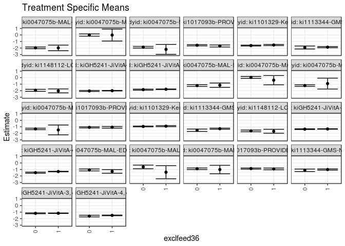

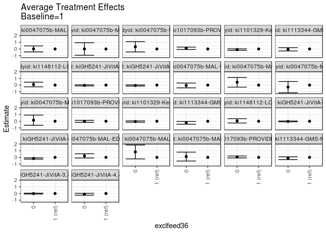

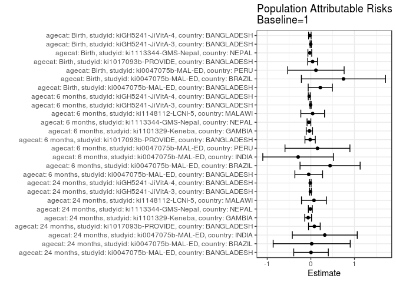

## Results Table

### Parameter: TSM

| agecat | studyid | country | intervention_level | baseline_level | estimate | ci_lower | ci_upper |
| --- | --- | --- | --- | --- | --- | --- | --- |
| Birth | ki0047075b-MAL-ED | BANGLADESH | 1 | NA | -1.2965477 | -1.5759449 | -1.0171505 |
| Birth | ki0047075b-MAL-ED | BANGLADESH | 0 | NA | -1.0721572 | -1.2232774 | -0.9210370 |
| Birth | ki0047075b-MAL-ED | BRAZIL | 1 | NA | -1.4240000 | -2.4288338 | -0.4191662 |
| Birth | ki0047075b-MAL-ED | BRAZIL | 0 | NA | -0.6136667 | -0.8950902 | -0.3322431 |
| Birth | ki0047075b-MAL-ED | PERU | 1 | NA | -1.0080000 | -1.6595862 | -0.3564138 |
| Birth | ki0047075b-MAL-ED | PERU | 0 | NA | -0.8886239 | -1.0108291 | -0.7664186 |
| Birth | ki1017093b-PROVIDE | BANGLADESH | 1 | NA | -0.9175858 | -1.0512085 | -0.7839631 |
| Birth | ki1017093b-PROVIDE | BANGLADESH | 0 | NA | -0.8606561 | -0.9487981 | -0.7725142 |
| Birth | ki1113344-GMS-Nepal | NEPAL | 1 | NA | -1.0062315 | -1.1025965 | -0.9098665 |
| Birth | ki1113344-GMS-Nepal | NEPAL | 0 | NA | -1.1259569 | -1.3176739 | -0.9342399 |
| Birth | kiGH5241-JiVitA-3 | BANGLADESH | 1 | NA | -1.1724105 | -1.2107027 | -1.1341183 |
| Birth | kiGH5241-JiVitA-3 | BANGLADESH | 0 | NA | -1.1864281 | -1.2499418 | -1.1229145 |
| Birth | kiGH5241-JiVitA-4 | BANGLADESH | 1 | NA | -1.5008487 | -1.5538587 | -1.4478387 |
| Birth | kiGH5241-JiVitA-4 | BANGLADESH | 0 | NA | -1.6114922 | -1.7404358 | -1.4825486 |
| 6 months | ki0047075b-MAL-ED | BANGLADESH | 1 | NA | -1.1593372 | -1.4922353 | -0.8264392 |
| 6 months | ki0047075b-MAL-ED | BANGLADESH | 0 | NA | -1.2142872 | -1.3415075 | -1.0870669 |
| 6 months | ki0047075b-MAL-ED | BRAZIL | 1 | NA | -0.3898364 | -1.1004988 | 0.3208261 |
| 6 months | ki0047075b-MAL-ED | BRAZIL | 0 | NA | 0.0344218 | -0.1112310 | 0.1800746 |
| 6 months | ki0047075b-MAL-ED | INDIA | 1 | NA | -0.9138889 | -1.7478752 | -0.0799025 |
| 6 months | ki0047075b-MAL-ED | INDIA | 0 | NA | -1.2171354 | -1.3367146 | -1.0975563 |
| 6 months | ki0047075b-MAL-ED | PERU | 1 | NA | -1.4791667 | -2.2344014 | -0.7239319 |
| 6 months | ki0047075b-MAL-ED | PERU | 0 | NA | -1.3241165 | -1.4338053 | -1.2144278 |
| 6 months | ki1017093b-PROVIDE | BANGLADESH | 1 | NA | -1.0692549 | -1.2014374 | -0.9370723 |
| 6 months | ki1017093b-PROVIDE | BANGLADESH | 0 | NA | -1.0852173 | -1.1717290 | -0.9987056 |
| 6 months | ki1101329-Keneba | GAMBIA | 1 | NA | -0.9020942 | -0.9886924 | -0.8154961 |
| 6 months | ki1101329-Keneba | GAMBIA | 0 | NA | -0.9451539 | -1.0037704 | -0.8865374 |
| 6 months | ki1113344-GMS-Nepal | NEPAL | 1 | NA | -1.2902791 | -1.3773291 | -1.2032291 |
| 6 months | ki1113344-GMS-Nepal | NEPAL | 0 | NA | -1.5253937 | -1.7104443 | -1.3403432 |
| 6 months | ki1148112-LCNI-5 | MALAWI | 1 | NA | -1.6816004 | -1.9804419 | -1.3827590 |
| 6 months | ki1148112-LCNI-5 | MALAWI | 0 | NA | -1.6265785 | -1.7579007 | -1.4952563 |
| 6 months | kiGH5241-JiVitA-3 | BANGLADESH | 1 | NA | -1.3325492 | -1.3645241 | -1.3005744 |
| 6 months | kiGH5241-JiVitA-3 | BANGLADESH | 0 | NA | -1.3603770 | -1.4145951 | -1.3061589 |
| 6 months | kiGH5241-JiVitA-4 | BANGLADESH | 1 | NA | -1.3144676 | -1.3558916 | -1.2730436 |
| 6 months | kiGH5241-JiVitA-4 | BANGLADESH | 0 | NA | -1.4854333 | -1.5754725 | -1.3953940 |
| 24 months | ki0047075b-MAL-ED | BANGLADESH | 1 | NA | -1.9832171 | -2.4120316 | -1.5544027 |
| 24 months | ki0047075b-MAL-ED | BANGLADESH | 0 | NA | -1.9717662 | -2.1033179 | -1.8402145 |
| 24 months | ki0047075b-MAL-ED | BRAZIL | 1 | NA | -0.0123684 | -0.9289806 | 0.9042438 |
| 24 months | ki0047075b-MAL-ED | BRAZIL | 0 | NA | -0.0086402 | -0.1813920 | 0.1641116 |
| 24 months | ki0047075b-MAL-ED | INDIA | 1 | NA | -2.2088889 | -2.9737293 | -1.4440485 |
| 24 months | ki0047075b-MAL-ED | INDIA | 0 | NA | -1.8758837 | -2.0028856 | -1.7488818 |
| 24 months | ki1017093b-PROVIDE | BANGLADESH | 1 | NA | -1.6830291 | -1.8380165 | -1.5280416 |
| 24 months | ki1017093b-PROVIDE | BANGLADESH | 0 | NA | -1.5783678 | -1.6735581 | -1.4831776 |
| 24 months | ki1101329-Keneba | GAMBIA | 1 | NA | -1.5364703 | -1.6277005 | -1.4452402 |
| 24 months | ki1101329-Keneba | GAMBIA | 0 | NA | -1.6244516 | -1.6920440 | -1.5568592 |
| 24 months | ki1113344-GMS-Nepal | NEPAL | 1 | NA | -1.8718312 | -1.9654597 | -1.7782027 |
| 24 months | ki1113344-GMS-Nepal | NEPAL | 0 | NA | -1.9194288 | -2.1491386 | -1.6897189 |
| 24 months | ki1148112-LCNI-5 | MALAWI | 1 | NA | -2.0370204 | -2.3412734 | -1.7327675 |
| 24 months | ki1148112-LCNI-5 | MALAWI | 0 | NA | -1.9458111 | -2.1031357 | -1.7884865 |
| 24 months | kiGH5241-JiVitA-3 | BANGLADESH | 1 | NA | -2.0033346 | -2.0459291 | -1.9607400 |
| 24 months | kiGH5241-JiVitA-3 | BANGLADESH | 0 | NA | -2.0452966 | -2.1230979 | -1.9674953 |
| 24 months | kiGH5241-JiVitA-4 | BANGLADESH | 1 | NA | -1.7791553 | -1.8222103 | -1.7361002 |
| 24 months | kiGH5241-JiVitA-4 | BANGLADESH | 0 | NA | -1.8365516 | -1.9171815 | -1.7559218 |

### Parameter: E(Y)

| agecat | studyid | country | intervention_level | baseline_level | estimate | ci_lower | ci_upper |
| --- | --- | --- | --- | --- | --- | --- | --- |
| Birth | ki0047075b-MAL-ED | BANGLADESH | NA | NA | -1.0802262 | -1.2151319 | -0.9453206 |
| Birth | ki0047075b-MAL-ED | BRAZIL | NA | NA | -0.6760000 | -0.9521457 | -0.3998543 |
| Birth | ki0047075b-MAL-ED | PERU | NA | NA | -0.8913004 | -1.0115814 | -0.7710195 |
| Birth | ki1017093b-PROVIDE | BANGLADESH | NA | NA | -0.8769592 | -0.9559693 | -0.7979491 |
| Birth | ki1113344-GMS-Nepal | NEPAL | NA | NA | -1.0299620 | -1.1192344 | -0.9406896 |
| Birth | kiGH5241-JiVitA-3 | BANGLADESH | NA | NA | -1.1758733 | -1.2120647 | -1.1396819 |
| Birth | kiGH5241-JiVitA-4 | BANGLADESH | NA | NA | -1.5234724 | -1.5733491 | -1.4735957 |
| 6 months | ki0047075b-MAL-ED | BANGLADESH | NA | NA | -1.2077639 | -1.3255735 | -1.0899543 |
| 6 months | ki0047075b-MAL-ED | BRAZIL | NA | NA | 0.0510207 | -0.0930194 | 0.1950608 |
| 6 months | ki0047075b-MAL-ED | INDIA | NA | NA | -1.2054220 | -1.3250470 | -1.0857970 |
| 6 months | ki0047075b-MAL-ED | PERU | NA | NA | -1.3275368 | -1.4361710 | -1.2189025 |
| 6 months | ki1017093b-PROVIDE | BANGLADESH | NA | NA | -1.0855583 | -1.1591292 | -1.0119875 |
| 6 months | ki1101329-Keneba | GAMBIA | NA | NA | -0.9355822 | -0.9858754 | -0.8852889 |
| 6 months | ki1113344-GMS-Nepal | NEPAL | NA | NA | -1.3337634 | -1.4135810 | -1.2539459 |
| 6 months | ki1148112-LCNI-5 | MALAWI | NA | NA | -1.6395956 | -1.7592633 | -1.5199278 |
| 6 months | kiGH5241-JiVitA-3 | BANGLADESH | NA | NA | -1.3384308 | -1.3675493 | -1.3093123 |
| 6 months | kiGH5241-JiVitA-4 | BANGLADESH | NA | NA | -1.3514886 | -1.3904044 | -1.3125729 |
| 24 months | ki0047075b-MAL-ED | BANGLADESH | NA | NA | -1.9789151 | -2.1055330 | -1.8522972 |
| 24 months | ki0047075b-MAL-ED | BRAZIL | NA | NA | 0.0071006 | -0.1615817 | 0.1757828 |
| 24 months | ki0047075b-MAL-ED | INDIA | NA | NA | -1.8892634 | -2.0152690 | -1.7632578 |
| 24 months | ki1017093b-PROVIDE | BANGLADESH | NA | NA | -1.6022704 | -1.6857342 | -1.5188065 |
| 24 months | ki1101329-Keneba | GAMBIA | NA | NA | -1.5981956 | -1.6534947 | -1.5428965 |
| 24 months | ki1113344-GMS-Nepal | NEPAL | NA | NA | -1.8830717 | -1.9710591 | -1.7950844 |
| 24 months | ki1148112-LCNI-5 | MALAWI | NA | NA | -1.9651323 | -2.1053230 | -1.8249415 |
| 24 months | kiGH5241-JiVitA-3 | BANGLADESH | NA | NA | -2.0131814 | -2.0513347 | -1.9750280 |
| 24 months | kiGH5241-JiVitA-4 | BANGLADESH | NA | NA | -1.7922845 | -1.8313538 | -1.7532153 |

### Parameter: ATE

| agecat | studyid | country | intervention_level | baseline_level | estimate | ci_lower | ci_upper |
| --- | --- | --- | --- | --- | --- | --- | --- |
| Birth | ki0047075b-MAL-ED | BANGLADESH | 1 | 1 | 0.0000000 | 0.0000000 | 0.0000000 |
| Birth | ki0047075b-MAL-ED | BANGLADESH | 0 | 1 | 0.2243905 | -0.0953439 | 0.5441249 |
| Birth | ki0047075b-MAL-ED | BRAZIL | 1 | 1 | 0.0000000 | 0.0000000 | 0.0000000 |
| Birth | ki0047075b-MAL-ED | BRAZIL | 0 | 1 | 0.8103333 | -0.2331657 | 1.8538323 |
| Birth | ki0047075b-MAL-ED | PERU | 1 | 1 | 0.0000000 | 0.0000000 | 0.0000000 |
| Birth | ki0047075b-MAL-ED | PERU | 0 | 1 | 0.1193761 | -0.5435709 | 0.7823232 |
| Birth | ki1017093b-PROVIDE | BANGLADESH | 1 | 1 | 0.0000000 | 0.0000000 | 0.0000000 |
| Birth | ki1017093b-PROVIDE | BANGLADESH | 0 | 1 | 0.0569297 | -0.0899685 | 0.2038279 |
| Birth | ki1113344-GMS-Nepal | NEPAL | 1 | 1 | 0.0000000 | 0.0000000 | 0.0000000 |
| Birth | ki1113344-GMS-Nepal | NEPAL | 0 | 1 | -0.1197254 | -0.3277678 | 0.0883169 |
| Birth | kiGH5241-JiVitA-3 | BANGLADESH | 1 | 1 | 0.0000000 | 0.0000000 | 0.0000000 |
| Birth | kiGH5241-JiVitA-3 | BANGLADESH | 0 | 1 | -0.0140176 | -0.0787855 | 0.0507502 |
| Birth | kiGH5241-JiVitA-4 | BANGLADESH | 1 | 1 | 0.0000000 | 0.0000000 | 0.0000000 |
| Birth | kiGH5241-JiVitA-4 | BANGLADESH | 0 | 1 | -0.1106435 | -0.2493600 | 0.0280730 |
| 6 months | ki0047075b-MAL-ED | BANGLADESH | 1 | 1 | 0.0000000 | 0.0000000 | 0.0000000 |
| 6 months | ki0047075b-MAL-ED | BANGLADESH | 0 | 1 | -0.0549500 | -0.4114220 | 0.3015221 |
| 6 months | ki0047075b-MAL-ED | BRAZIL | 1 | 1 | 0.0000000 | 0.0000000 | 0.0000000 |
| 6 months | ki0047075b-MAL-ED | BRAZIL | 0 | 1 | 0.4242582 | -0.3024671 | 1.1509834 |
| 6 months | ki0047075b-MAL-ED | INDIA | 1 | 1 | 0.0000000 | 0.0000000 | 0.0000000 |
| 6 months | ki0047075b-MAL-ED | INDIA | 0 | 1 | -0.3032465 | -1.1457620 | 0.5392690 |
| 6 months | ki0047075b-MAL-ED | PERU | 1 | 1 | 0.0000000 | 0.0000000 | 0.0000000 |
| 6 months | ki0047075b-MAL-ED | PERU | 0 | 1 | 0.1550501 | -0.6081086 | 0.9182088 |
| 6 months | ki1017093b-PROVIDE | BANGLADESH | 1 | 1 | 0.0000000 | 0.0000000 | 0.0000000 |
| 6 months | ki1017093b-PROVIDE | BANGLADESH | 0 | 1 | -0.0159624 | -0.1720504 | 0.1401255 |
| 6 months | ki1101329-Keneba | GAMBIA | 1 | 1 | 0.0000000 | 0.0000000 | 0.0000000 |
| 6 months | ki1101329-Keneba | GAMBIA | 0 | 1 | -0.0430597 | -0.1437965 | 0.0576771 |
| 6 months | ki1113344-GMS-Nepal | NEPAL | 1 | 1 | 0.0000000 | 0.0000000 | 0.0000000 |
| 6 months | ki1113344-GMS-Nepal | NEPAL | 0 | 1 | -0.2351146 | -0.4393675 | -0.0308617 |
| 6 months | ki1148112-LCNI-5 | MALAWI | 1 | 1 | 0.0000000 | 0.0000000 | 0.0000000 |
| 6 months | ki1148112-LCNI-5 | MALAWI | 0 | 1 | 0.0550219 | -0.2676457 | 0.3776896 |
| 6 months | kiGH5241-JiVitA-3 | BANGLADESH | 1 | 1 | 0.0000000 | 0.0000000 | 0.0000000 |
| 6 months | kiGH5241-JiVitA-3 | BANGLADESH | 0 | 1 | -0.0278278 | -0.0867999 | 0.0311444 |
| 6 months | kiGH5241-JiVitA-4 | BANGLADESH | 1 | 1 | 0.0000000 | 0.0000000 | 0.0000000 |
| 6 months | kiGH5241-JiVitA-4 | BANGLADESH | 0 | 1 | -0.1709657 | -0.2681456 | -0.0737857 |
| 24 months | ki0047075b-MAL-ED | BANGLADESH | 1 | 1 | 0.0000000 | 0.0000000 | 0.0000000 |
| 24 months | ki0047075b-MAL-ED | BANGLADESH | 0 | 1 | 0.0114509 | -0.4379423 | 0.4608441 |
| 24 months | ki0047075b-MAL-ED | BRAZIL | 1 | 1 | 0.0000000 | 0.0000000 | 0.0000000 |
| 24 months | ki0047075b-MAL-ED | BRAZIL | 0 | 1 | 0.0037282 | -0.9295795 | 0.9370359 |
| 24 months | ki0047075b-MAL-ED | INDIA | 1 | 1 | 0.0000000 | 0.0000000 | 0.0000000 |
| 24 months | ki0047075b-MAL-ED | INDIA | 0 | 1 | 0.3330052 | -0.4423079 | 1.1083183 |
| 24 months | ki1017093b-PROVIDE | BANGLADESH | 1 | 1 | 0.0000000 | 0.0000000 | 0.0000000 |
| 24 months | ki1017093b-PROVIDE | BANGLADESH | 0 | 1 | 0.1046612 | -0.0721530 | 0.2814755 |
| 24 months | ki1101329-Keneba | GAMBIA | 1 | 1 | 0.0000000 | 0.0000000 | 0.0000000 |
| 24 months | ki1101329-Keneba | GAMBIA | 0 | 1 | -0.0879813 | -0.2000187 | 0.0240562 |
| 24 months | ki1113344-GMS-Nepal | NEPAL | 1 | 1 | 0.0000000 | 0.0000000 | 0.0000000 |
| 24 months | ki1113344-GMS-Nepal | NEPAL | 0 | 1 | -0.0475976 | -0.2941241 | 0.1989290 |
| 24 months | ki1148112-LCNI-5 | MALAWI | 1 | 1 | 0.0000000 | 0.0000000 | 0.0000000 |
| 24 months | ki1148112-LCNI-5 | MALAWI | 0 | 1 | 0.0912093 | -0.2531358 | 0.4355544 |
| 24 months | kiGH5241-JiVitA-3 | BANGLADESH | 1 | 1 | 0.0000000 | 0.0000000 | 0.0000000 |
| 24 months | kiGH5241-JiVitA-3 | BANGLADESH | 0 | 1 | -0.0419620 | -0.1286596 | 0.0447355 |
| 24 months | kiGH5241-JiVitA-4 | BANGLADESH | 1 | 1 | 0.0000000 | 0.0000000 | 0.0000000 |
| 24 months | kiGH5241-JiVitA-4 | BANGLADESH | 0 | 1 | -0.0573964 | -0.1447977 | 0.0300049 |

### Parameter: PAR

| agecat | studyid | country | intervention_level | baseline_level | estimate | ci_lower | ci_upper |
| --- | --- | --- | --- | --- | --- | --- | --- |
| Birth | ki0047075b-MAL-ED | BANGLADESH | 1 | NA | 0.2163215 | -0.0608728 | 0.4935157 |
| Birth | ki0047075b-MAL-ED | BRAZIL | 1 | NA | 0.7480000 | -0.2166815 | 1.7126815 |
| Birth | ki0047075b-MAL-ED | PERU | 1 | NA | 0.1166996 | -0.5296780 | 0.7630771 |
| Birth | ki1017093b-PROVIDE | BANGLADESH | 1 | NA | 0.0406266 | -0.0708809 | 0.1521341 |
| Birth | ki1113344-GMS-Nepal | NEPAL | 1 | NA | -0.0237305 | -0.0673213 | 0.0198603 |
| Birth | kiGH5241-JiVitA-3 | BANGLADESH | 1 | NA | -0.0034628 | -0.0177891 | 0.0108636 |
| Birth | kiGH5241-JiVitA-4 | BANGLADESH | 1 | NA | -0.0226237 | -0.0513706 | 0.0061232 |
| 6 months | ki0047075b-MAL-ED | BANGLADESH | 1 | NA | -0.0484266 | -0.3661975 | 0.2693442 |
| 6 months | ki0047075b-MAL-ED | BRAZIL | 1 | NA | 0.4408571 | -0.2480845 | 1.1297988 |
| 6 months | ki0047075b-MAL-ED | INDIA | 1 | NA | -0.2915331 | -1.1015400 | 0.5184738 |
| 6 months | ki0047075b-MAL-ED | PERU | 1 | NA | 0.1516299 | -0.5924548 | 0.8957146 |
| 6 months | ki1017093b-PROVIDE | BANGLADESH | 1 | NA | -0.0163035 | -0.1351336 | 0.1025267 |
| 6 months | ki1101329-Keneba | GAMBIA | 1 | NA | -0.0334879 | -0.1059171 | 0.0389413 |
| 6 months | ki1113344-GMS-Nepal | NEPAL | 1 | NA | -0.0434843 | -0.0867066 | -0.0002621 |
| 6 months | ki1148112-LCNI-5 | MALAWI | 1 | NA | 0.0420049 | -0.2296322 | 0.3136420 |
| 6 months | kiGH5241-JiVitA-3 | BANGLADESH | 1 | NA | -0.0058816 | -0.0194909 | 0.0077278 |
| 6 months | kiGH5241-JiVitA-4 | BANGLADESH | 1 | NA | -0.0370211 | -0.0591576 | -0.0148845 |
| 24 months | ki0047075b-MAL-ED | BANGLADESH | 1 | NA | 0.0043020 | -0.3921127 | 0.4007168 |
| 24 months | ki0047075b-MAL-ED | BRAZIL | 1 | NA | 0.0194690 | -0.8637198 | 0.9026578 |
| 24 months | ki0047075b-MAL-ED | INDIA | 1 | NA | 0.3196255 | -0.4245861 | 1.0638371 |
| 24 months | ki1017093b-PROVIDE | BANGLADESH | 1 | NA | 0.0807587 | -0.0530372 | 0.2145546 |
| 24 months | ki1101329-Keneba | GAMBIA | 1 | NA | -0.0617253 | -0.1398231 | 0.0163725 |
| 24 months | ki1113344-GMS-Nepal | NEPAL | 1 | NA | -0.0112406 | -0.0570502 | 0.0345691 |
| 24 months | ki1148112-LCNI-5 | MALAWI | 1 | NA | 0.0718882 | -0.2144009 | 0.3581772 |
| 24 months | kiGH5241-JiVitA-3 | BANGLADESH | 1 | NA | -0.0098468 | -0.0299312 | 0.0102375 |
| 24 months | kiGH5241-JiVitA-4 | BANGLADESH | 1 | NA | -0.0131292 | -0.0322369 | 0.0059784 |